# Projeto florestas aleatórias

Para este projeto, estaremos explorando dados disponíveis publicamente de LendingClub.com. Lending Club conecta pessoas que precisam de dinheiro (mutuários) com pessoas que têm dinheiro (investidores). Felizmente, como investidor, você gostaria de investir em pessoas que mostraram um perfil de ter uma alta probabilidade de pagá-lo de volta. Vamos tentar criar um modelo que ajude a prever isso.

O clube de empréstimo teve um [ano muito interessante em 2016](https://en.wikipedia.org/wiki/Lending_Club#2016), então vamos verificar alguns de seus dados e ter em mente o contexto. Esses dados são de antes mesmo de serem públicos.

Utilizaremos os dados de empréstimos de 2007-2010 e tentaremos classificar e prever se o mutuário pagou o empréstimo na íntegra. Você pode baixar os dados de [aqui](https://www.lendingclub.com/info/download-data.action) ou apenas usar o csv já fornecido. Recomenda-se que você use o csv fornecido, uma vez que foi limpo dos valores de NA.

Aqui estão o que as colunas representam:

- credit.policy: 1 se o cliente atender aos critérios de subscrição de crédito da LendingClub.com e 0 caso contrário.
- purpose: O objetivo do empréstimo (possíveis valores "credit_card", "debt_consolidation", "educacional", "major_purchase", "small_business" e "all_other").
- int.rate: a taxa de juros do empréstimo (uma taxa de 11% seria armazenada como 0.11). Os mutuários julgados por LendingClub.com para serem mais arriscados recebem taxas de juros mais elevadas.
- installment: as parcelas mensais devidas pelo mutuário se o empréstimo for financiado.
- log.annual.inc: O log natural da renda anual auto-relatada do mutuário.
- dti: Ratio dívida / rendimento do tomador do empréstimo (montante da dívida dividido pela receita anual).
- fico: a pontuação de crédito FICO do mutuário.
- days.with.cr.line: O número de dias em que o mutuário teve uma linha de crédito.
- revol.bal: Saldo rotativo do mutuário (montante não pago no final do ciclo de cobrança do cartão de crédito).
- revol.util: taxa de utilização da linha rotativa do mutuário (o valor da linha de crédito usada em relação ao crédito total disponível).
- inq.last.6mths: número de consultas do mutuário por credores nos últimos 6 meses.
- delinq.2yrs: o número de vezes que o mutuário havia passado mais de 30 dias em um pagamento nos últimos 2 anos.
- pub.rec: O número de registros públicos depreciativos do mutuário (arquivamentos de falências, ônus fiscais ou julgamentos).

# Importar bibliotecas

** Importe as bibliotecas usuais para pandas e plotagem. Você pode importar sklearn mais tarde. **

```python
import pandas as pd
import numpy as np
import matplotlib.pyplot as plt
import seaborn as sns
from warnings import filterwarnings
filterwarnings('ignore')
plt.style.use('default')
```

## Obter dados

** Use pandas para ler loan_data.csv como um DataFrame chamado loans. **

```python
df_loans = pd.read_csv("data/loan_data.csv")
df_loans.head()
```

|  | credit.policy | purpose | int.rate | installment | log.annual.inc | dti | fico | days.with.cr.line | revol.bal | revol.util | inq.last.6mths | delinq.2yrs | pub.rec | not.fully.paid |
| --- | --- | --- | --- | --- | --- | --- | --- | --- | --- | --- | --- | --- | --- | --- |
| 0 | 1 | debt_consolidation | 0.1189 | 829.10 | 11.350407 | 19.48 | 737 | 5639.958333 | 28854 | 52.1 | 0 | 0 | 0 | 0 |
| 1 | 1 | credit_card | 0.1071 | 228.22 | 11.082143 | 14.29 | 707 | 2760.000000 | 33623 | 76.7 | 0 | 0 | 0 | 0 |
| 2 | 1 | debt_consolidation | 0.1357 | 366.86 | 10.373491 | 11.63 | 682 | 4710.000000 | 3511 | 25.6 | 1 | 0 | 0 | 0 |
| 3 | 1 | debt_consolidation | 0.1008 | 162.34 | 11.350407 | 8.10 | 712 | 2699.958333 | 33667 | 73.2 | 1 | 0 | 0 | 0 |
| 4 | 1 | credit_card | 0.1426 | 102.92 | 11.299732 | 14.97 | 667 | 4066.000000 | 4740 | 39.5 | 0 | 1 | 0 | 0 |

** Use os métodos info(), head(), e describe() em loans. **

```python
df_loans.info()
```

```
<class 'pandas.core.frame.DataFrame'>
RangeIndex: 9578 entries, 0 to 9577
Data columns (total 14 columns):
 #   Column             Non-Null Count  Dtype
---  ------             --------------  -----
 0   credit.policy      9578 non-null   int64
 1   purpose            9578 non-null   object
 2   int.rate           9578 non-null   float64
 3   installment        9578 non-null   float64
 4   log.annual.inc     9578 non-null   float64
 5   dti                9578 non-null   float64
 6   fico               9578 non-null   int64
 7   days.with.cr.line  9578 non-null   float64
 8   revol.bal          9578 non-null   int64
 9   revol.util         9578 non-null   float64
 10  inq.last.6mths     9578 non-null   int64
 11  delinq.2yrs        9578 non-null   int64
 12  pub.rec            9578 non-null   int64
 13  not.fully.paid     9578 non-null   int64
dtypes: float64(6), int64(7), object(1)
memory usage: 1.0+ MB
```

```python
df_loans.describe()
```

|  | credit.policy | int.rate | installment | log.annual.inc | dti | fico | days.with.cr.line | revol.bal | revol.util | inq.last.6mths | delinq.2yrs | pub.rec | not.fully.paid |
| --- | --- | --- | --- | --- | --- | --- | --- | --- | --- | --- | --- | --- | --- |
| count | 9578.000000 | 9578.000000 | 9578.000000 | 9578.000000 | 9578.000000 | 9578.000000 | 9578.000000 | 9.578000e+03 | 9578.000000 | 9578.000000 | 9578.000000 | 9578.000000 | 9578.000000 |
| mean | 0.804970 | 0.122640 | 319.089413 | 10.932117 | 12.606679 | 710.846314 | 4560.767197 | 1.691396e+04 | 46.799236 | 1.577469 | 0.163708 | 0.062122 | 0.160054 |
| std | 0.396245 | 0.026847 | 207.071301 | 0.614813 | 6.883970 | 37.970537 | 2496.930377 | 3.375619e+04 | 29.014417 | 2.200245 | 0.546215 | 0.262126 | 0.366676 |
| min | 0.000000 | 0.060000 | 15.670000 | 7.547502 | 0.000000 | 612.000000 | 178.958333 | 0.000000e+00 | 0.000000 | 0.000000 | 0.000000 | 0.000000 | 0.000000 |
| 25% | 1.000000 | 0.103900 | 163.770000 | 10.558414 | 7.212500 | 682.000000 | 2820.000000 | 3.187000e+03 | 22.600000 | 0.000000 | 0.000000 | 0.000000 | 0.000000 |
| 50% | 1.000000 | 0.122100 | 268.950000 | 10.928884 | 12.665000 | 707.000000 | 4139.958333 | 8.596000e+03 | 46.300000 | 1.000000 | 0.000000 | 0.000000 | 0.000000 |
| 75% | 1.000000 | 0.140700 | 432.762500 | 11.291293 | 17.950000 | 737.000000 | 5730.000000 | 1.824950e+04 | 70.900000 | 2.000000 | 0.000000 | 0.000000 | 0.000000 |
| max | 1.000000 | 0.216400 | 940.140000 | 14.528354 | 29.960000 | 827.000000 | 17639.958330 | 1.207359e+06 | 119.000000 | 33.000000 | 13.000000 | 5.000000 | 1.000000 |

```python
df_loans.head()
```

|  | credit.policy | purpose | int.rate | installment | log.annual.inc | dti | fico | days.with.cr.line | revol.bal | revol.util | inq.last.6mths | delinq.2yrs | pub.rec | not.fully.paid |
| --- | --- | --- | --- | --- | --- | --- | --- | --- | --- | --- | --- | --- | --- | --- |
| 0 | 1 | debt_consolidation | 0.1189 | 829.10 | 11.350407 | 19.48 | 737 | 5639.958333 | 28854 | 52.1 | 0 | 0 | 0 | 0 |
| 1 | 1 | credit_card | 0.1071 | 228.22 | 11.082143 | 14.29 | 707 | 2760.000000 | 33623 | 76.7 | 0 | 0 | 0 | 0 |
| 2 | 1 | debt_consolidation | 0.1357 | 366.86 | 10.373491 | 11.63 | 682 | 4710.000000 | 3511 | 25.6 | 1 | 0 | 0 | 0 |
| 3 | 1 | debt_consolidation | 0.1008 | 162.34 | 11.350407 | 8.10 | 712 | 2699.958333 | 33667 | 73.2 | 1 | 0 | 0 | 0 |
| 4 | 1 | credit_card | 0.1426 | 102.92 | 11.299732 | 14.97 | 667 | 4066.000000 | 4740 | 39.5 | 0 | 1 | 0 | 0 |

# Análise exploratória de dados

Vamos fazer alguma visualização de dados! Usaremos os recursos de plotagem incorporados ao seaborn e ao pandas, mas sinta-se livre para usar qualquer biblioteca que você deseja. Não se preocupe com as cores, apenas se preocupe em obter a idéia principal do plot.

**Crie um histograma de duas distribuições FICO umas sobre as outras, uma para cada um dos valores possíveis de credit.policy**.

*Nota: Isto é complicado, sinta-se à vontade para fazer referência às soluções. Você provavelmente precisará de uma linha de código para cada histograma, eu também recomendo usar o .hist() incorporado ao pandas.*

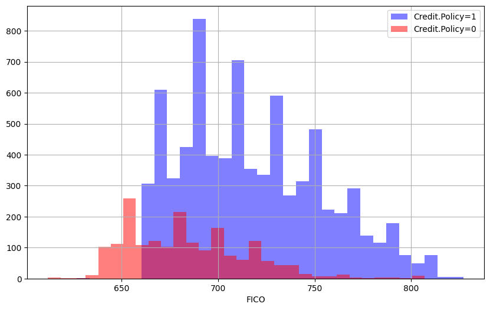

```python
plt.figure(figsize=(10, 6))
df_loans[df_loans["credit.policy"] == 1]["fico"].hist(
    alpha=0.5, color="blue", bins=30, label="Credit.Policy=1"
)

df_loans[df_loans["credit.policy"] == 0]["fico"].hist(
    alpha=0.5, color="red", bins=30, label="Credit.Policy=0"
)
plt.legend()
plt.xlabel("FICO")
```

O gráfico mostra a distribuição das pontuações FICO dos clientes, separando-os conforme o valor da coluna credit.policy (1 ou 0). Observa-se que:

- Ambos os grupos apresentam distribuições semelhantes, com a maioria dos clientes concentrados em faixas intermediárias de FICO.
- Clientes que atendem à política de crédito **(credit.policy = 1)** tendem a ter pontuações FICO ligeiramente mais altas, predominando na parte direita do gráfico (azul).
- Já os clientes que não atendem à política **(credit.policy = 0)** aparecem mais nas faixas de FICO mais baixas (vermelho).
- Há sobreposição entre as distribuições, mas a separação indica que a política de crédito favorece clientes com melhor pontuação FICO.

Em resumo, a política de crédito seleciona principalmente clientes com FICO mais alto, enquanto clientes com FICO mais baixo são mais rejeitados.

** Crie uma figura semelhante, mas dessa vez use a coluna not.fully.paid. **

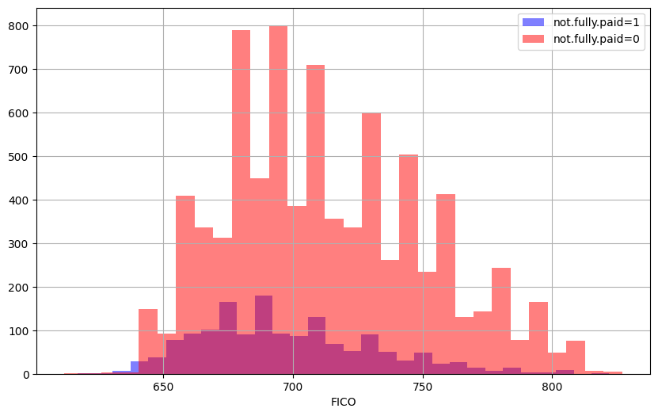

```python
plt.figure(figsize=(10, 6))
df_loans[df_loans["not.fully.paid"] == 1]["fico"].hist(
    alpha=0.5, color="blue", bins=30, label="not.fully.paid=1"
)
df_loans[df_loans["not.fully.paid"] == 0]["fico"].hist(
    alpha=0.5, color="red", bins=30, label="not.fully.paid=0"
)
plt.legend()
plt.xlabel("FICO")
```

### Analise da distribuição de FICO por status de pagamento do empréstimo

O gráfico apresenta a distribuição das pontuações FICO dos clientes, separando-os conforme o status da coluna not.fully.paid (1 ou 0). As principais tendências observadas são:

- Clientes que não quitaram totalmente o empréstimo **(not.fully.paid = 1, azul)** tendem a ter pontuações FICO mais baixas.
- Clientes que quitaram totalmente o empréstimo **(not.fully.paid = 0, vermelho)** concentram-se em faixas mais altas de FICO.
- Existe sobreposição entre as distribuições, mas a diferença de concentração indica que uma pontuação FICO mais alta está associada a maior probabilidade de pagamento total do empréstimo.
- A maioria dos clientes está nas faixas intermediárias de FICO, mas o risco de inadimplência aumenta conforme a pontuação diminui.

Resumindo: quanto menor a pontuação FICO, maior a chance de não pagamento total do empréstimo.

** Crie um countplot usando seaborn mostrando a contagens de empréstimos por finalidade, com a matiz de cor definido por not.fully.paid. **

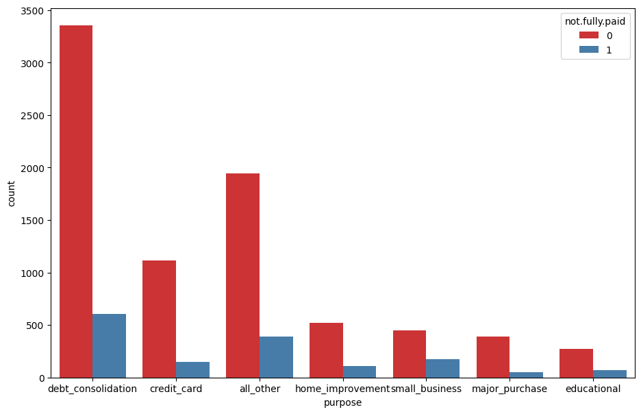

```python
plt.figure(figsize=(11, 7))
sns.countplot(x="purpose", hue="not.fully.paid", data=df_loans, palette="Set1")
```

### Analise da contagem de empréstimos por finalidade e status de pagamento

Resumindo: a inadimplência varia conforme a finalidade do empréstimo, sendo mais frequente em algumas categorias específicas.

** Veja a tendência entre o índice FICO e a taxa de juros. Recrie o seguinte jointplot. **

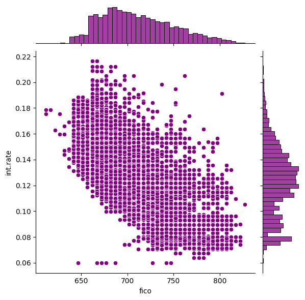

```python
sns.jointplot(x="fico", y="int.rate", data=df_loans, color="purple")
```

### Analise da relação entre pontuação FICO e taxa de juros

O gráfico jointplot mostra a relação entre a pontuação FICO e a taxa de juros (int.rate). As principais tendências observadas são:

- Existe uma relação inversa: quanto maior a pontuação FICO do cliente, menor tende a ser a taxa de juros oferecida.
- Clientes com FICO baixo pagam taxas de juros mais altas, enquanto clientes com FICO alto recebem taxas mais baixas.
- A dispersão dos pontos indica que, apesar da tendência geral, há alguma variação nas taxas para uma mesma faixa de FICO.

Resumindo: clientes com melhor pontuação de crédito conseguem empréstimos com juros menores.

** Crie os seguintes lmplots para ver se a tendência diferiu entre not.fully.paid e credit.policy. Verifique a documentação para lmplot() se você não consegue descobrir como separá-lo em colunas. **

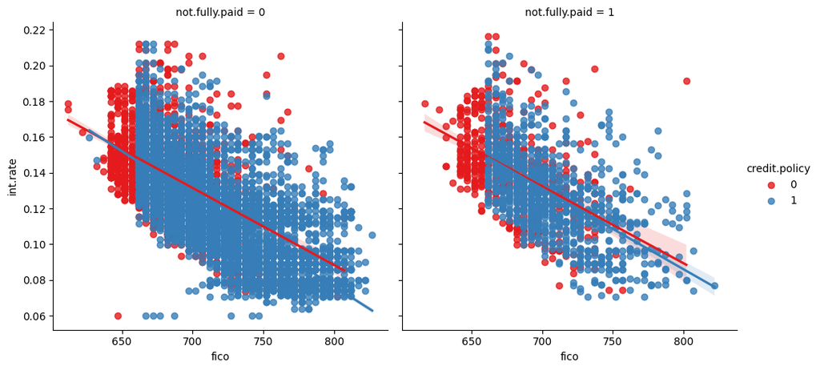

```python
plt.figure(figsize=(11, 7))
sns.lmplot(
    y="int.rate",
    x="fico",
    data=df_loans,
    hue="credit.policy",
    col="not.fully.paid",
    palette="Set1",
)
```

### Analise da relação entre pontuação FICO, taxa de juros, status de pagamento e política de crédito

# Configurando os dados

Vamos nos preparar para configurar nossos dados para o nosso modelo de classificação de florestas aleatórias!

** Verifique loans.info() novamente. **

```python
df_loans.info()
```

```
<class 'pandas.core.frame.DataFrame'>
RangeIndex: 9578 entries, 0 to 9577
Data columns (total 14 columns):
 #   Column             Non-Null Count  Dtype
---  ------             --------------  -----
 0   credit.policy      9578 non-null   int64
 1   purpose            9578 non-null   object
 2   int.rate           9578 non-null   float64
 3   installment        9578 non-null   float64
 4   log.annual.inc     9578 non-null   float64
 5   dti                9578 non-null   float64
 6   fico               9578 non-null   int64
 7   days.with.cr.line  9578 non-null   float64
 8   revol.bal          9578 non-null   int64
 9   revol.util         9578 non-null   float64
 10  inq.last.6mths     9578 non-null   int64
 11  delinq.2yrs        9578 non-null   int64
 12  pub.rec            9578 non-null   int64
 13  not.fully.paid     9578 non-null   int64
dtypes: float64(6), int64(7), object(1)
memory usage: 1.0+ MB
```

## Recursos categóricos

Vamos transformar a coluna **purpose** em categórica. Isso significa que precisamos transformá-los usando variáveis dummys para que Sklearn possa compreendê-las. Vamos fazer isso em um passo de limpeza usando pd.get_dummies.

** Crie uma lista de 1 elemento contendo a string 'purpose'. Chame esta lista de cat_feats. **

```python
cat_feats = ["purpose"]
```

** Agora use "pd.get_dummies(loans, columns = cat_feats, drop_first = True)" para criar um DataFrame maior fixo que tenha novas colunas de recursos com variáveis dummy. Chame este dataframe de final_data. **

```python
final_data = pd.get_dummies(df_loans, columns=cat_feats, drop_first=True)
```

```python
final_data
```

|  | credit.policy | int.rate | installment | log.annual.inc | dti | fico | days.with.cr.line | revol.bal | revol.util | inq.last.6mths | delinq.2yrs | pub.rec | not.fully.paid | purpose_credit_card | purpose_debt_consolidation | purpose_educational | purpose_home_improvement | purpose_major_purchase | purpose_small_business |
| --- | --- | --- | --- | --- | --- | --- | --- | --- | --- | --- | --- | --- | --- | --- | --- | --- | --- | --- | --- |
| 0 | 1 | 0.1189 | 829.10 | 11.350407 | 19.48 | 737 | 5639.958333 | 28854 | 52.1 | 0 | 0 | 0 | 0 | False | True | False | False | False | False |
| 1 | 1 | 0.1071 | 228.22 | 11.082143 | 14.29 | 707 | 2760.000000 | 33623 | 76.7 | 0 | 0 | 0 | 0 | True | False | False | False | False | False |
| 2 | 1 | 0.1357 | 366.86 | 10.373491 | 11.63 | 682 | 4710.000000 | 3511 | 25.6 | 1 | 0 | 0 | 0 | False | True | False | False | False | False |
| 3 | 1 | 0.1008 | 162.34 | 11.350407 | 8.10 | 712 | 2699.958333 | 33667 | 73.2 | 1 | 0 | 0 | 0 | False | True | False | False | False | False |
| 4 | 1 | 0.1426 | 102.92 | 11.299732 | 14.97 | 667 | 4066.000000 | 4740 | 39.5 | 0 | 1 | 0 | 0 | True | False | False | False | False | False |
| ... | ... | ... | ... | ... | ... | ... | ... | ... | ... | ... | ... | ... | ... | ... | ... | ... | ... | ... | ... |
| 9573 | 0 | 0.1461 | 344.76 | 12.180755 | 10.39 | 672 | 10474.000000 | 215372 | 82.1 | 2 | 0 | 0 | 1 | False | False | False | False | False | False |
| 9574 | 0 | 0.1253 | 257.70 | 11.141862 | 0.21 | 722 | 4380.000000 | 184 | 1.1 | 5 | 0 | 0 | 1 | False | False | False | False | False | False |
| 9575 | 0 | 0.1071 | 97.81 | 10.596635 | 13.09 | 687 | 3450.041667 | 10036 | 82.9 | 8 | 0 | 0 | 1 | False | True | False | False | False | False |
| 9576 | 0 | 0.1600 | 351.58 | 10.819778 | 19.18 | 692 | 1800.000000 | 0 | 3.2 | 5 | 0 | 0 | 1 | False | False | False | True | False | False |
| 9577 | 0 | 0.1392 | 853.43 | 11.264464 | 16.28 | 732 | 4740.000000 | 37879 | 57.0 | 6 | 0 | 0 | 1 | False | True | False | False | False | False |

9578 rows × 19 columns

## Divisão Treino-Teste de dados

Agora é hora de dividir nossos dados em um conjunto de treinamento e um conjunto de testes!

** Use sklearn para dividir seus dados em um conjunto de treinamento e um conjunto de testes como fizemos no passado. **

```python
from sklearn.model_selection import train_test_split
```

```python
X = final_data.drop("not.fully.paid", axis=1)
y = final_data["not.fully.paid"]
X_train, X_test, y_train, y_test = train_test_split(
    X, y, test_size=0.30, random_state=42
)
```

## Training a Decision Tree Model

Vamos começar treinando uma única árvore de decisão primeiro!

** Import DecisionTreeClassifier **

```python
from sklearn.tree import DecisionTreeClassifier
```

** Crie uma instância de DecisionTreeClassifier() chamada dtree e fite-a com os dados de treinamento. **

```python
dtree = DecisionTreeClassifier(random_state=42)
```

```python
dtree.fit(X_train, y_train)
```

```
DecisionTreeClassifier(random_state=42)
```

## Previsões e avaliação da árvore de decisão

** Faça previsões do conjunto de teste e crie um relatório de classificação e uma matriz de confusão. **

```python
predictions = dtree.predict(X_test)
```

```python
from sklearn.metrics import classification_report, confusion_matrix
```

```python
print(classification_report(y_test, predictions))
print(confusion_matrix(y_test, predictions))
```

```
              precision    recall  f1-score   support

           0       0.85      0.84      0.84      2408
           1       0.20      0.21      0.20       466

    accuracy                           0.74      2874
   macro avg       0.52      0.52      0.52      2874
weighted avg       0.74      0.74      0.74      2874

[[2015  393]
 [ 368   98]]
```

### Análise da árvore de decisão

A análise das métricas e da matriz de confusão mostra:

- Alta acurácia: O modelo acerta a maioria das previsões, principalmente para a classe de clientes que quitaram o empréstimo (classe 0).
- Desbalanceamento: O recall e a precisão para a classe 1 (não quitou) são menores, indicando que o modelo tem mais dificuldade em identificar corretamente os inadimplentes.
- Matriz de confusão: A maior parte dos falsos negativos ocorre na classe 1, ou seja, clientes inadimplentes sendo classificados como adimplentes.
- Tendência: O modelo tende a prever mais clientes como adimplentes, errando mais ao prever inadimplentes.

Resumindo: o modelo é bom para identificar quem vai pagar, mas tem desempenho limitado para prever inadimplentes, devido ao desbalanceamento das classes.

## Treinando o modelo de florestas aleatórias

Agora é hora de treinar nosso modelo!

** Crie uma instância da classe RandomForestClassifier e ajuste-a aos nossos dados de treinamento da etapa anterior. **

```python
from sklearn.ensemble import RandomForestClassifier
```

```python
rfc = RandomForestClassifier(
    n_estimators=300,
    random_state=42,
)
```

```python
rfc.fit(X_train, y_train)
```

```
RandomForestClassifier(n_estimators=300, random_state=42)
```

## Previsões e Avaliação

Vamos prever os valores do y_test e avaliar o nosso modelo.

**Preveja a classe de not.fully.paid para os dados X_test.**

```python
predictions = rfc.predict(X_test)
```

**Agora crie um relatório de classificação dos resultados.**

```python
from sklearn.metrics import classification_report, confusion_matrix
```

```python
print(classification_report(y_test, predictions))
print(confusion_matrix(y_test, predictions))
```

```
              precision    recall  f1-score   support

           0       0.84      0.99      0.91      2408
           1       0.39      0.02      0.04       466

    accuracy                           0.84      2874
   macro avg       0.62      0.51      0.47      2874
weighted avg       0.77      0.84      0.77      2874

[[2394   14]
 [ 457    9]]
```

### Análise do modelo de Floresta Aleatória

A análise das métricas e da matriz de confusão do modelo de Floresta Aleatória mostra:

- Alta acurácia geral, com o modelo acertando a maioria das previsões para clientes que quitaram o empréstimo (classe 0).
- Desempenho inferior para a classe 1 (inadimplentes): precisão e recall menores, indicando dificuldade em identificar corretamente quem não quitou o empréstimo.
- Matriz de confusão: a maioria dos erros ocorre ao classificar inadimplentes como adimplentes (falsos negativos).
- Tendência: o modelo favorece a classe majoritária (adimplentes), errando mais ao prever inadimplentes.

Resumindo: o modelo é eficiente para identificar bons pagadores, mas ainda apresenta limitações para detectar inadimplentes, principalmente devido ao desbalanceamento das classes.